# Course Project: Practical Machine Learning

# Human Activity Recognition

#### Author: Daniel Kinpara

#### Date: August, 2015

### 1. Introduction

The goal of this project is to predict the quality of execution of a weight lifting exercise. In order to do that, data from four accelerometers installed in a belt, forearm (glove), arm, and dumbbell of six individuals were used to build the training dataset. They were asked to perform 10 repetitions of the Unilateral Dumbbell Biceps Curl in five different ways:

- Class A: correct;
- Class B: wrong – throwing the elbows to the front;
- Class C: wrong – lifting the dumbbell only halfway;
- Class D: wrong – lowering the dumbbell only halfway;
- Class E: wrong – throwing the hips to the front.

The dataset used to train the model can be [download here](https://d396qusza40orc.cloudfront.net/predmachlearn/pml-training.csv). The original data source is from [Velloso et al. (2013)](http://groupware.les.inf.puc-rio.br/public/papers/2013.Velloso.QAR-WLE.pdf).

The packages used for this study are listed below:

```r
library(AppliedPredictiveModeling)
library(lattice)
library(ggplot2)
library(caret)
library(e1071)
library(randomForest)
```

### 2. The dataset

The original dataset has 160 variables and 19,622 observations. It has five major groups of variables: 1) bookkeeping; 2) arm sensor; 3) forearm sensor; 4) belt sensor; and 5) dumbbell sensor. Velloso et al. (2013) used the Euler angles of each of the four sensors to calculate eight features: mean, variance, standard deviation, max, min, amplitude, kurtosis, and skewness. Most of the features’ data are “NA”.

The outcome variable is the variable **classe**, with five levels (A to E). In order to find the model that best predict the five classes, only the sensor readings were used. Each sensor have 13 different measurements, as follow: gyroscope 3-axis, accelerometer 3-axis, magnetometer 3-axis, total acceleration, roll, pitch, and yaw. The variable **num_window** gives the time frame of the readings. So, the total number of variables is 54. The variable list below was the dataset used for the present study.

```r
setwd("~/Documents/")                                           # The directory
                                                                # of the file.
dados <- read.csv("pml-training.csv",
                header = TRUE, sep = ",", dec = ".",
                na.strings = c("NA", ""))                       # Blank spaces
                                                                # are also NA.

dados <- dados[ ,7:160]                                         # Bookkeeping
                                                                # variables are
                                                                # trimmed.
colunasNA <- apply(!is.na(dados), 2, sum)                       # Sums the # of
                                                                # NA in each
                                                                # column.
semNA <- colunasNA == 19622                                     # Tests when                                                                    # whole column
                                                                # is of NA.
dados <- dados[ ,semNA]                                         # Removes the
                                                                # NA columns.
```

The final dataset structure is:

```
## 'data.frame':    19622 obs. of  54 variables:
##  $ num_window          : int  11 11 11 12 12 12 12 12 12 12 ...
##  $ roll_belt           : num  1.41 1.41 1.42 1.48 1.48 1.45 1.42 1.42 1.43 1.45 ...
##  $ pitch_belt          : num  8.07 8.07 8.07 8.05 8.07 8.06 8.09 8.13 8.16 8.17 ...
##  $ yaw_belt            : num  -94.4 -94.4 -94.4 -94.4 -94.4 -94.4 -94.4 -94.4 -94.4 -94.4 ...
##  $ total_accel_belt    : int  3 3 3 3 3 3 3 3 3 3 ...
##  $ gyros_belt_x        : num  0 0.02 0 0.02 0.02 0.02 0.02 0.02 0.02 0.03 ...
##  $ gyros_belt_y        : num  0 0 0 0 0.02 0 0 0 0 0 ...
##  $ gyros_belt_z        : num  -0.02 -0.02 -0.02 -0.03 -0.02 -0.02 -0.02 -0.02 -0.02 0 ...
##  $ accel_belt_x        : int  -21 -22 -20 -22 -21 -21 -22 -22 -20 -21 ...
##  $ accel_belt_y        : int  4 4 5 3 2 4 3 4 2 4 ...
##  $ accel_belt_z        : int  22 22 23 21 24 21 21 21 24 22 ...
##  $ magnet_belt_x       : int  -3 -7 -2 -6 -6 0 -4 -2 1 -3 ...
##  $ magnet_belt_y       : int  599 608 600 604 600 603 599 603 602 609 ...
##  $ magnet_belt_z       : int  -313 -311 -305 -310 -302 -312 -311 -313 -312 -308 ...
```

[output cut: 40 more lines]

In order to best determine the model accuracy, the training dataset was splitted in two groups, the training group (*dadosTreino*) and the test group (*dadosTeste*). The proportion is 70% for training and 30% for testing.

```r
divisao <- createDataPartition(y = dados$classe, p = 0.7, list=FALSE)
dadosTreino <- dados[divisao, ]
dadosTeste <- dados[-divisao, ]
```

- *dadosTreino* dimension (obs, var): **13737, 54**.
- *dadosTeste* dimension (obs, var): **5885, 54**.

### 3. The model

Velloso et al. (2013) mentioned in their paper that they used Random Forest (RF) method as the first approach to determine the performance recognition model. They justify the use of RF method due to the usual noise present in the sensor readings. Kelly (2014) explains that RF is an improvement over bagged trees (bootstraping resampling). In the bootstrap process, the strongest predictor is used in the first split, what makes the trees to be quite similar. The result is some very correlated trees, “hiding” the variance in the dataset (keeps it high). RF makes each split to consider only a subset of the predictors. So, part of the splits will not even consider the strongest predictor.

In the present study, a RF method was used to train a prediction model. The model obtained was tested with a non-exhaustive 10-fold cross-validation resampling, as Velloso et al. (2013) have done.

```r
set.seed(2015)
modeloRF <- train(classe ~ .,data = dadosTreino, method = "rf",
                  trControl = trainControl(method = "cv", number = 10))
```

```
## Random Forest
##
## 13737 samples
##    53 predictor
##     5 classes: 'A', 'B', 'C', 'D', 'E'
##
## No pre-processing
## Resampling: Cross-Validated (10 fold)
## Summary of sample sizes: 12364, 12362, 12362, 12365, 12363, 12364, ...
## Resampling results across tuning parameters:
##
##   mtry  Accuracy   Kappa      Accuracy SD  Kappa SD
##    2    0.9935211  0.9918045  0.001798714  0.002275422
##   27    0.9973790  0.9966847  0.001790961  0.002265619
##   53    0.9945399  0.9930928  0.002232718  0.002825343
##
## Accuracy was used to select the optimal model using  the largest value.
## The final value used for the model was mtry = 27.
```

The final model variables are presented below. It was used the Gini index to order the variables importance in the final model.

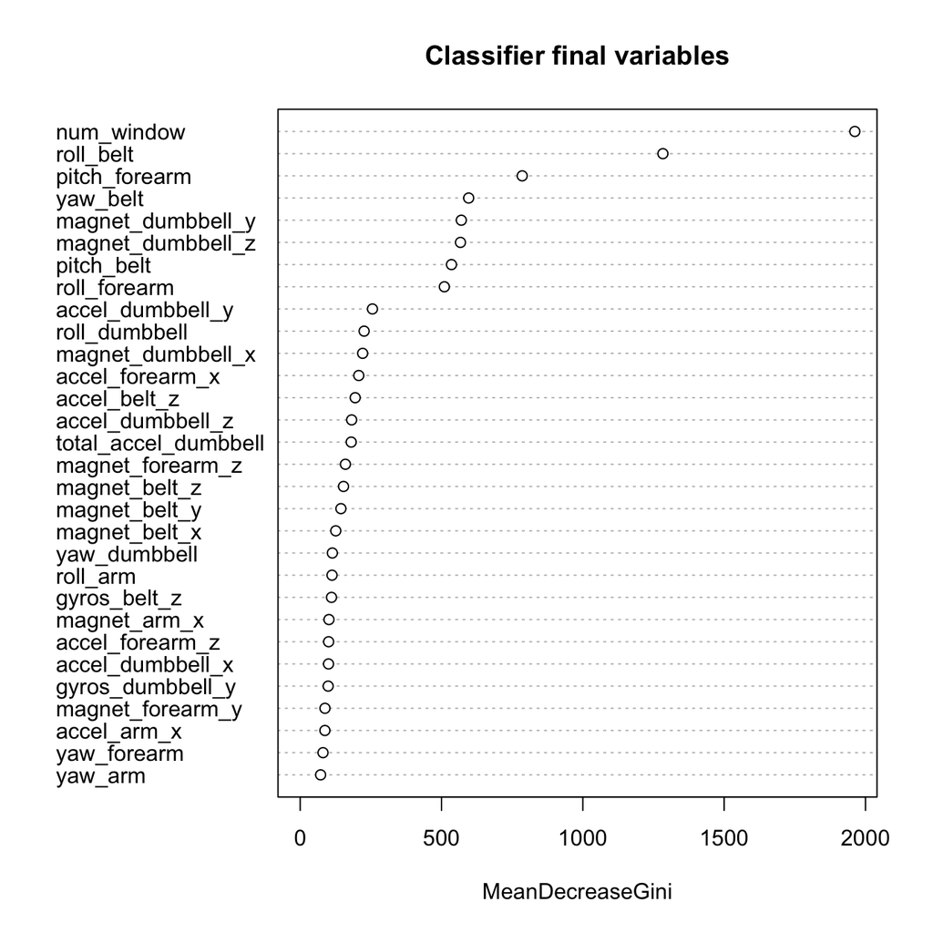

As mentioned before, Velloso et al. (2013) used eight calculated features to built their model. To select the features, they used Hall (1999) algorithm based on correlation configured to use “Best First” strategy for backtracking. The selected 17 features were:

- Belt sensor: mean and variance of the roll, maximum, range and variance of the accelerometer vector, variance of the gyro, and variance of the magnetometer;
- Arm sensor: variance of the accelerometer vector and the maximum and minimum of the magnetometer;
- Dumbbell sensor: maximum of the acceleration, variance of the gyro, and maximum and minimum of the magnetometer;
- Glove sensor: sum of the pitch and the maximum and minimum of the gyro.

### 4. Error Estimates

The error can be estimated through an out-of-bag sampling process (OOB). The result obtained by the trained model was 0.24%. As the confusion matrix shows, most of the classification errors happens in the classes **B** and **D**. They are wrong exercises movements, when the subject throws the elbows to the front and when lowers the dumbbell only halfway, respectively. In the **D** case, given that “half” can be very subjective, that may explain why is difficult to classify these mistaken movements.

```
##
## Call:
##  randomForest(x = x, y = y, mtry = param$mtry)
##                Type of random forest: classification
##                      Number of trees: 500
## No. of variables tried at each split: 27
##
##         OOB estimate of  error rate: 0.24%
## Confusion matrix:
##      A    B    C    D    E  class.error
## A 3905    1    0    0    0 0.0002560164
## B    6 2645    6    1    0 0.0048908954
## C    0    4 2392    0    0 0.0016694491
## D    0    0    9 2242    1 0.0044404973
## E    0    0    0    5 2520 0.0019801980
```

```
## Confusion Matrix and Statistics
##
##           Reference
## Prediction    A    B    C    D    E
##          A 1674    0    0    0    0
##          B    0 1139    0    0    0
##          C    0    0 1026    3    0
##          D    0    0    0  961    0
##          E    0    0    0    0 1082
##
## Overall Statistics
##
##                Accuracy : 0.9995
##                  95% CI : (0.9985, 0.9999)
##     No Information Rate : 0.2845
##     P-Value [Acc > NIR] : < 2.2e-16
##
##                   Kappa : 0.9994
##  Mcnemar's Test P-Value : NA
##
## Statistics by Class:
##
##                      Class: A Class: B Class: C Class: D Class: E
## Sensitivity            1.0000   1.0000   1.0000   0.9969   1.0000
## Specificity            1.0000   1.0000   0.9994   1.0000   1.0000
## Pos Pred Value         1.0000   1.0000   0.9971   1.0000   1.0000
## Neg Pred Value         1.0000   1.0000   1.0000   0.9994   1.0000
## Prevalence             0.2845   0.1935   0.1743   0.1638   0.1839
## Detection Rate         0.2845   0.1935   0.1743   0.1633   0.1839
## Detection Prevalence   0.2845   0.1935   0.1749   0.1633   0.1839
## Balanced Accuracy      1.0000   1.0000   0.9997   0.9984   1.0000
```

### 5. Cited Literature

Velloso, E.; Bulling, A.; Gellersen, H.; Ugulino, W.; Fuks, H. *Qualitative Activity Recognition of Weight Lifting Exercises*. Proceedings of 4th International Conference in Cooperation with SIGCHI (Augmented Human ’13) . Stuttgart, Germany: ACM SIGCHI, 2013.

Hall, M. A. *Correlation-based Feature Subset Selection for Machine Learning*. PhD thesis, Department of Computer Science, University of Waikato, Hamilton, New Zealand, Apr. 1999.

Kelly, R. *Bagging, Random Forests, Boosting*. [accessed 2014 August 21]. http://www.rmdk.ca/boosting_forests_bagging.html